# Introduction to `mrgsolve` 2

Shen Cheng

2024-10-11

# Outline

- Model parameters: `[ param ]` and `[ theta ]`
- Model specifications
  - Covariate model: `[ main ]` (i.e., `[ pk ]`)
  - Random effects: `[ omega ]` and `[ sigma ]`
  - Import `NONMEM` estimates: `[ nmext ]` and `[ nmxml ]`
  - Models in Closed form: `[ pkmodel ]`
  - `[ plugin ]`
  - Other blocks
- Model validations

## An example model

`NONMEM` model `./wk6/nm-model/106.mod`

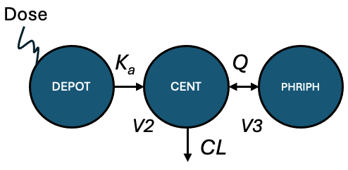

## An example model

`./wk6/mrg-model/106.cpp` which is a translated `mrgsolve` model from the `NONMEM` model `./wk6/nm-model/106.mod`

```cpp
[ prob ]
  ECP8506 mrgsolve model for illustration
  This model requires mrgsolve >= 1.0.3

[ pkmodel ] cmt = "GUT,CENT,PERIPH", depot = TRUE

[ param ]
  WT   = 70
  EGFR = 90
  ALB  = 4.5
  AGE  = 35

[ theta ] @annotated
  0.4431220   : log(TVKA)
  4.1190600   : log(TVV2)
  1.1719900   : log(TVCL)
  4.2094000   : log(TVV3)
  1.2845700   : log(TVQ)
  0.4847790   : log(CLEGFR)
  -0.0377291  : log(CLAGE)
  0.4187480   : log(CLALB)

[ omega ] @block
  0.219
  0.0668 0.0824
  0.121  0.0703 0.114

[ sigma ] @block
  0.0399

[ pk ]
  double V2WT   = log(WT/70.0);
  double CLWT   = log(WT/70.0)*0.75;
  double CLEGFR = log(EGFR/90.0)*THETA(6);
  double CLAGE  = log(AGE/35.0)*THETA(7);
  double V3WT   = log(WT/70.0);
  double QWT    = log(WT/70.0)*0.75;
  double CLALB  = log(ALB/4.5)*THETA(8);

  double KA  = exp(THETA(1) + ETA(1));
  double V2  = exp(THETA(2) + V2WT + ETA(2));
  double CL  = exp(THETA(3) + CLWT + CLEGFR + CLAGE + CLALB + ETA(3));
  double V3  = exp(THETA(4) + V3WT);
  double Q   = exp(THETA(5) + QWT);

  double S2 = V2/1000.0; //; dose in mcg, conc in mcg/mL

[ error ]
  double IPRED = CENT/S2;
  double Y = IPRED * (1+EPS(1));

[ capture ] CL V2 IPRED Y
```

## Load the model

```r
suppressPackageStartupMessages(library(here))
suppressPackageStartupMessages(library(tidyverse))
suppressPackageStartupMessages(library(mrgsolve))

mod <- mread(model = "106.cpp",
             project = here("wk6/mrg-model"))
```

```
Building 106_cpp ... done.
```

## Check the model

```r
mod
param(mod)
omat(mod)
smat(mod)
see(mod)
```

# Model parameters

`mrgsolve` maintains a parameter list (`name` / `value` pairs):

- This list is used by default (under `[ param ]` or `[ theta ]`) if nothing else is done.
- The parameter values in this list can be updated.

```cpp
[ prob ]
  ECP8506 mrgsolve model for illustration
  This model requires mrgsolve >= 1.0.3

[ pkmodel ] cmt = "GUT,CENT,PERIPH", depot = TRUE

[ param ]
  WT   = 70
  EGFR = 90
  ALB  = 4.5
  AGE  = 35

[ theta ] @annotated
  0.4431220   : log(TVKA)
  4.1190600   : log(TVV2)
  1.1719900   : log(TVCL)
  4.2094000   : log(TVV3)
  1.2845700   : log(TVQ)
  0.4847790   : log(CLEGFR)
  -0.0377291  : log(CLAGE)
  0.4187480   : log(CLALB)

[ omega ] @block
  0.219
  0.0668 0.0824
  0.121  0.0703 0.114

[ sigma ] @block
  0.0399

[ pk ]
  double V2WT   = log(WT/70.0);
  double CLWT   = log(WT/70.0)*0.75;
  double CLEGFR = log(EGFR/90.0)*THETA(6);
  double CLAGE  = log(AGE/35.0)*THETA(7);
  double V3WT   = log(WT/70.0);
  double QWT    = log(WT/70.0)*0.75;
  double CLALB  = log(ALB/4.5)*THETA(8);

  double KA  = exp(THETA(1) + ETA(1));
  double V2  = exp(THETA(2) + V2WT + ETA(2));
  double CL  = exp(THETA(3) + CLWT + CLEGFR + CLAGE + CLALB + ETA(3));
  double V3  = exp(THETA(4) + V3WT);
  double Q   = exp(THETA(5) + QWT);

  double S2 = V2/1000.0; //; dose in mcg, conc in mcg/mL

[ error ]
  double IPRED = CENT/S2;
  double Y = IPRED * (1+EPS(1));

[ capture ] CL V2 IPRED Y WT EGFR ALB AGE
```

## Specify model parameters

```cpp
[ param ]
  WT   = 70
  EGFR = 90
  ALB  = 4.5
  AGE  = 35

[ theta ] @annotated
  0.4431220   : log(TVKA)
  4.1190600   : log(TVV2)
  1.1719900   : log(TVCL)
  4.2094000   : log(TVV3)
  1.2845700   : log(TVQ)
  0.4847790   : log(CLEGFR)
  -0.0377291  : log(CLAGE)
  0.4187480   : log(CLALB)
```

```cpp
[ param ]
  WT   = 70
  EGFR = 90
  ALB  = 4.5
  AGE  = 35

[ theta ]
  0.4431220
  4.1190600
  1.1719900
  4.2094000
  1.2845700
  0.4847790
  -0.0377291
  0.4187480
```

## Specify model parameters

```cpp
[ param ]
  WT   = 70
  EGFR = 90
  ALB  = 4.5
  AGE  = 35

[ theta ] @annotated
  0.4431220   : log(TVKA)
  4.1190600   : log(TVV2)
  1.1719900   : log(TVCL)
  4.2094000   : log(TVV3)
  1.2845700   : log(TVQ)
  0.4847790   : log(CLEGFR)
  -0.0377291  : log(CLAGE)
  0.4187480   : log(CLALB)
```

```cpp
[ param ]
  WT   = 70
  EGFR = 90
  ALB  = 4.5
  AGE  = 35
  THETA1 = 0.4431220
  THETA2 = 4.1190600
  THETA3 = 1.1719900
  THETA4 = 4.2094000
  THETA5 = 1.2845700
  THETA6 = 0.4847790
  THETA7 = -0.0377291
  THETA8 = 0.4187480
```

## Update model parameters

- Prior to the simulation.
  - `param()`
  - `update()`
- During the simulation

## `param()`

```r
mod$WT
```

```
[1] 70
```

```r
mod <- param(mod, WT=80)
mod$WT
```

```
[1] 80
```

## `update()`

```r
mod$WT
```

```
[1] 80
```

```r
mod <- update(mod, param = list(WT = 60))
mod$WT
```

```
[1] 60
```

## Update using a `list` object

```r
p <- list(WT = 70.2, FOO = 1) # A list object
mod <- param(mod, p)
mod <- update(mod, param=p)
mod$WT
```

```
[1] 70.2
```

## Update using a `data.frame` object

```r
# A data frame object
data <- data.frame(WT = 80.1, BAR = 2)
mod <- param(mod, data)
# mod <- update(mod, param=data)
mod$WT
```

```
[1] 80.1
```

```r
# A data frame object with multiple records
data <- data.frame(WT = c(70, 80.5), BAR = 2)
mod <- param(mod, data[2,])
# mod <- update(mod, param=data[2,])
mod$WT
```

```
[1] 80.5
```

## Update during the simulation

```r
out <- mrgsim_df(mod, param = list(WT = 65))
unique(out$WT)
```

```
[1] 65
```

## Update during the simulation

```r
withr::with_seed(12131,
                 data <- data.frame(
                 ID=1:3, TIME=0, AMT=100, CMT=1, EVID=1,
                 WT = rnorm(3, 70, 10), # Simulate 3 random WT
                 EGFR = rnorm(3, 90, 10), # Simulate 3 random EGFR
                 ALB = rnorm(3, 4.5, 2),  # Simulate 3 random ALB
                 AGE = 50)) # AGE=50 for everyone
data
```

```
  ID TIME AMT CMT EVID       WT      EGFR        ALB AGE
1  1    0 100   1    1 85.22736  95.47835 1.72194263  50
2  2    0 100   1    1 42.17078 102.73307 4.24730145  50
3  3    0 100   1    1 73.57190  95.16679 0.06696794  50
```

## `data_set()`

```r
out <-
  mod %>%
  data_set(data) %>% # Simulate using `data_set()`
  zero_re() %>% # Simulate without random effect
  mrgsim(delta = 0.1, end = 24)

plot(out, "WT,EGFR,ALB,AGE,IPRED")
```

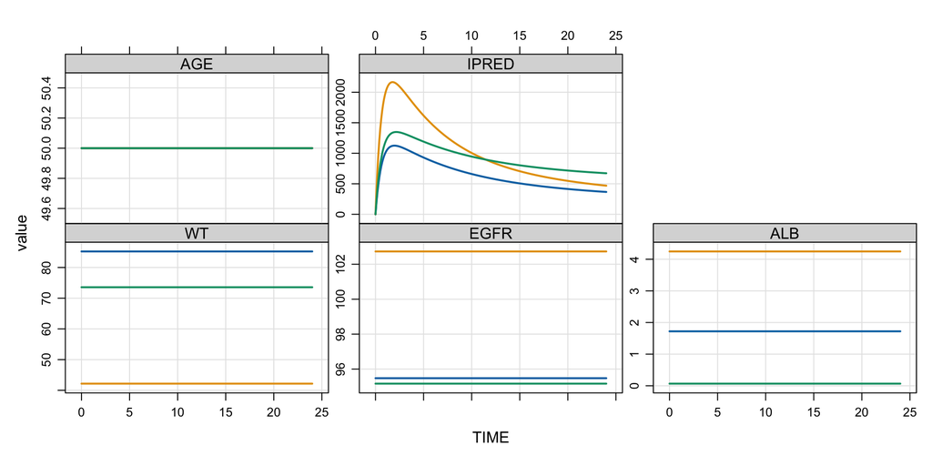

## Check if the names match

```r
param(mod)
```

```
 Model parameters (N=12):
 name   value . name   value
 AGE    35    | THETA4 4.21
 ALB    4.5   | THETA5 1.28
 EGFR   90    | THETA6 0.485
 THETA1 0.443 | THETA7 -0.0377
 THETA2 4.12  | THETA8 0.419
 THETA3 1.17  | WT     80.5
```

```r
inventory(mod, data)
```

## `[ input ]`

New in `mrgsolve` 1.2.0, you can use the `$INPUT` block.

```cpp
[ param ]
  WT   = 70
  EGFR = 90
  ALB  = 4.5
  AGE  = 35
  THETA1 = 0.4431220
  THETA2 = 4.1190600
  THETA3 = 1.1719900
  THETA4 = 4.2094000
  THETA5 = 1.2845700
  THETA6 = 0.4847790
  THETA7 = -0.0377291
  THETA8 = 0.4187480
```

```cpp
[ input ]
  WT   = 70
  EGFR = 90
  ALB  = 4.5
  AGE  = 35

[ param ]
  THETA1 = 0.4431220
  THETA2 = 4.1190600
  THETA3 = 1.1719900
  THETA4 = 4.2094000
  THETA5 = 1.2845700
  THETA6 = 0.4847790
  THETA7 = -0.0377291
  THETA8 = 0.4187480
```

## Input tags

```r
param_tags(mod)
check_data_names(data, mod)
```

# Covariate model

Syntax in `[ main ]` and `[ pk ]` are in `C++`.

```cpp
[ prob ]
  ECP8506 mrgsolve model for illustration
  This model requires mrgsolve >= 1.0.3

[ pkmodel ] cmt = "GUT,CENT,PERIPH", depot = TRUE

[ param ]
  WT   = 70
  EGFR = 90
  ALB  = 4.5
  AGE  = 35

[ theta ] @annotated
  0.4431220   : log(TVKA)
  4.1190600   : log(TVV2)
  1.1719900   : log(TVCL)
  4.2094000   : log(TVV3)
  1.2845700   : log(TVQ)
  0.4847790   : log(CLEGFR)
  -0.0377291  : log(CLAGE)
  0.4187480   : log(CLALB)

[ omega ] @block
  0.219
  0.0668 0.0824
  0.121  0.0703 0.114

[ sigma ] @block
  0.0399

[ pk ]
  double V2WT   = log(WT/70.0);
  double CLWT   = log(WT/70.0)*0.75;
  double CLEGFR = log(EGFR/90.0)*THETA(6);
  double CLAGE  = log(AGE/35.0)*THETA(7);
  double V3WT   = log(WT/70.0);
  double QWT    = log(WT/70.0)*0.75;
  double CLALB  = log(ALB/4.5)*THETA(8);

  double KA  = exp(THETA(1) + ETA(1));
  double V2  = exp(THETA(2) + V2WT + ETA(2));
  double CL  = exp(THETA(3) + CLWT + CLEGFR + CLAGE + CLALB + ETA(3));
  double V3  = exp(THETA(4) + V3WT);
  double Q   = exp(THETA(5) + QWT);

  double S2 = V2/1000.0; //; dose in mcg, conc in mcg/mL

[ error ]
  double IPRED = CENT/S2;
  double Y = IPRED * (1+EPS(1));

[ capture ] CL V2 IPRED Y WT EGFR ALB AGE
```

## `C++` syntax

```cpp
double a = 0; // `double` is a data-type in C++
double b = 0; // similar to numeric in R
double c = 0; // `int` = integer
double d = 0; // `bool` = boolean

if(a == 2) b = 2;

if(b <= 2) {
  c=3;
} else {
  c=4;
}

d = a==2 ? 50 : 100;
```

## `C++` syntax

```cpp
double d = pow(base,exponent);
double e = exp(3);
double f = fabs(-4);
double g = sqrt(5);
double h = log(6);
double i = log10(7);
double j = floor(4.2);
double k = ceil(4.2);
```

$$d = base^{exponent} \\
e = e^3 \\
f = |-4| \\
g = \sqrt{5} \\
h = \ln{6} \\
i = \log_{10} 7 \\
j = \lfloor 4.2 \rfloor \\
k = \lceil 4.2 \rceil$$

## General rules

```cpp
$PK

double CL = TVCL * pow(WT/70, 0.75) * exp(ETA(1));
bool cure = false;
```

- Any valid `c++` code is allowed.
- Declare variable type (e.g., `double` for numeric variable; `bool` for logical variable).
- Use `;` behind each line of syntax.
- Case sensitive, use `exp` and `pow`, not `EXP` and `POW`.
- Lots of help on the web (https://en.cppreference.com/w/cpp).

## Caution

Be careful of integer division

```cpp
double result = 1/2; # 0
double result = 1.0/2.0; # 0.5
```

# Random effects

```cpp
[ prob ]
  ECP8506 mrgsolve model for illustration
  This model requires mrgsolve >= 1.0.3

[ pkmodel ] cmt = "GUT,CENT,PERIPH", depot = TRUE

[ param ]
  WT   = 70
  EGFR = 90
  ALB  = 4.5
  AGE  = 35

[ theta ] @annotated
  0.4431220   : log(TVKA)
  4.1190600   : log(TVV2)
  1.1719900   : log(TVCL)
  4.2094000   : log(TVV3)
  1.2845700   : log(TVQ)
  0.4847790   : log(CLEGFR)
  -0.0377291  : log(CLAGE)
  0.4187480   : log(CLALB)

[ omega ] @block
  0.219
  0.0668 0.0824
  0.121  0.0703 0.114

[ sigma ] @block
  0.0399

[ pk ]
  double V2WT   = log(WT/70.0);
  double CLWT   = log(WT/70.0)*0.75;
  double CLEGFR = log(EGFR/90.0)*THETA(6);
  double CLAGE  = log(AGE/35.0)*THETA(7);
  double V3WT   = log(WT/70.0);
  double QWT    = log(WT/70.0)*0.75;
  double CLALB  = log(ALB/4.5)*THETA(8);

  double KA  = exp(THETA(1) + ETA(1));
  double V2  = exp(THETA(2) + V2WT + ETA(2));
  double CL  = exp(THETA(3) + CLWT + CLEGFR + CLAGE + CLALB + ETA(3));
  double V3  = exp(THETA(4) + V3WT);
  double Q   = exp(THETA(5) + QWT);

  double S2 = V2/1000.0; //; dose in mcg, conc in mcg/mL

[ error ]
  double IPRED = CENT/S2;
  double Y = IPRED * (1+EPS(1));

[ capture ] CL V2 IPRED Y WT EGFR ALB AGE
```

## Block matrix

```cpp
[ omega ] @block
  0.219
  0.0668 0.0824
  0.121  0.0703 0.114
```

or

```cpp
[ omega ] @block
  0.219 0.0668 0.0824 0.121 0.0703 0.114
```

- Diagonal elements are **variance**.
- Off-diagonal elements are **covariance**.

$$\begin{bmatrix}
0.219 & 0.0668 & 0.121 \\
0.0668 & 0.0824 & 0.0703 \\
0.121 & 0.0703 & 0.114 \\
\end{bmatrix}$$

## Diagonal matrix

```cpp
[ omega ]
  0.219 0.0824 0.114
```

$$\begin{bmatrix}
0.219 & 0 & 0 \\
0 & 0.0824 & 0 \\
0 & 0 & 0.114 \\
\end{bmatrix}$$

## `@correlation`

```cpp
[ omega ] @correlation
  0.219
  0.497 0.0824
  0.766 0.725  0.114
```

$$Cor(X,Y) = \frac{Cov(X,Y)}{\sqrt{Var(X) \times Var(Y)}}$$

- Diagonal elements are still **variance**.
- Off-diagonal elements are **correlation**, not covariance.

## `[ omega ]` and `[ sigma ]`

```cpp
...
[ omega ] @block
  0.219
  0.0668 0.0824
  0.121  0.0703 0.114

[ sigma ] @block
  0.0399
...
[ pk ]
...
  double KA  = exp(THETA(1) + ETA(1));
  double V2  = exp(THETA(2) + V2WT + ETA(2));
  double CL  = exp(THETA(3) + CLWT + CLEGFR + CLAGE + CLALB + ETA(3));
...
[ error ]
  double IPRED = CENT/S2;
  double Y = IPRED * (1+EPS(1));
```

## `@label`

```cpp
...
[ omega ] @block @labels ETA_KA ETA_V2 ETA_CL
  0.219
  0.0668 0.0824
  0.121  0.0703 0.114

[ sigma ] @block
  0.0399
...
[ pk ]
...
  double KA  = exp(THETA(1) + ETA_KA);
  double V2  = exp(THETA(2) + V2WT + ETA_V2);
  double CL  = exp(THETA(3) + CLWT + CLEGFR + CLAGE + CLALB + ETA_CL);
...
[ error ]
  double IPRED = CENT/S2;
  double Y = IPRED * (1+EPS(1));
```

## `@annotated`

```cpp
...
[ omega ] @annotated @block
  0.219 : ETA on KA
  0.0668 0.0824 : ETA on V2
  0.121  0.0703 0.114 : ETA on CL

[ sigma ] @block
  0.0399
...
[ pk ]
...
  double KA  = exp(THETA(1) + + ETA(1));
  double V2  = exp(THETA(2) + V2WT + + ETA(2));
  double CL  = exp(THETA(3) + CLWT + CLEGFR + CLAGE + CLALB + + ETA(3));
...
[ error ]
  double IPRED = CENT/S2;
  double Y = IPRED * (1+EPS(1));
```

## Separated `[ omega ]`/`[ sigma ]`

Once separated, the `[ omega ]` matrix will behave as a diagonal matrix.

```cpp
...
[ omega ] @annotated
  0.219 : ETA on KA

[ omega ] @annotated
  0.0824 : ETA on V2

[ omega ] @annotated
  0.114 : ETA on CL

[ sigma ] @block
  0.0399
...
[ pk ]
...
  double KA  = exp(THETA(1) + + ETA(1));
  double V2  = exp(THETA(2) + V2WT + + ETA(2));
  double CL  = exp(THETA(3) + CLWT + CLEGFR + CLAGE + CLALB + + ETA(3));
...
[ error ]
  double IPRED = CENT/S2;
  double Y = IPRED * (1+EPS(1));
```

## `@name`

```cpp
...
[ omega ] @name KA
  0.219

[ omega ] @name V2
  0.0824

[ omega ] @name CL
  0.114

[ sigma ] @block
  0.0399
...
[ pk ]
...
  double KA  = exp(THETA(1) + + ETA(1));
  double V2  = exp(THETA(2) + V2WT + + ETA(2));
  double CL  = exp(THETA(3) + CLWT + CLEGFR + CLAGE + CLALB + + ETA(3));
...
[ error ]
  double IPRED = CENT/S2;
  double Y = IPRED * (1+EPS(1));
```

# Import `NONMEM` estimates

- Use `[ nmext ]` or `[ nmxml ]`
  - `[ nmext ]` reads from the `.ext` file.
    - Can be faster.
    - Doesn’t retain `[ omega ]` and `[ sigma ]` structure.
  - `[ nmxml ]` reads from the `.xml` file.
    - Can be slower.
    - Does retain `[ omega ]` and `[ sigma ]` structure.

## `[ nmext ]` and `[ nmxml ]`

If you have a `NONMEM` script with two `$OMEGA`

```cpp
...
$OMEGA BLOCK(2)
0.1
0.01 0.1

$OMEGA BLOCK(3)
0.1
0.01 0.1
0.01 0.01 0.1
...
```

- `[ nmext ]` loads OMEGA matrix as a 5x5 matrix.
- `[ nmxml ]` loads OMEGA matrix as a 2x2 matrix and a 3x3 matrix.

## `[ nmext ]`

```cpp
[ theta ] @annotated
  0.4431220   : log(TVKA)
  4.1190600   : log(TVV2)
  1.1719900   : log(TVCL)
  4.2094000   : log(TVV3)
  1.2845700   : log(TVQ)
  0.4847790   : log(CLEGFR)
  -0.0377291  : log(CLAGE)
  0.4187480   : log(CLALB)

[ omega ] @block
  0.219
  0.0668 0.0824
  0.121  0.0703 0.114

[ sigma ] @block
  0.0399
```

```cpp
[ nmext ]
path = "../nm-model/106/106.ext"
root = "cppfile"
```

`root = "cppfile"` look for `.ext` file relative to *where the model source code file is located*

```cpp
[ nmext ]
run = 106
project = "../nm-model/"
root = "cppfile"
```

This syntax will let `mrgsolve` model look for `../nm-model/106/106.ext`

## `[ nmxml ]`

```cpp
[ theta ] @annotated
  0.4431220   : log(TVKA)
  4.1190600   : log(TVV2)
  1.1719900   : log(TVCL)
  4.2094000   : log(TVV3)
  1.2845700   : log(TVQ)
  0.4847790   : log(CLEGFR)
  -0.0377291  : log(CLAGE)
  0.4187480   : log(CLALB)

[ omega ] @block
  0.219
  0.0668 0.0824
  0.121  0.0703 0.114

[ sigma ] @block
  0.0399
```

```cpp
[ nmxml ]
path = "../nm-model/106/106.xml"
root = "cppfile"
```

`root = "cppfile"` look for `.xml` file relative to *where the model source code file is located*

```cpp
[ nmxml ]
run = 106
project = "../nm-model/"
root = "cppfile"
```

This syntax will let `mrgsolve` model look for `../nm-model/106/106.xml`

# Models in closed form

Like `NONMEM`, `mrgsolve` also has “short-cut” to solve one- and two-compartment models with first order input in closed form using `[ pkmodel ]`, which usually results in substantial speed up.

## `NONMEM $SUBROUTINE`

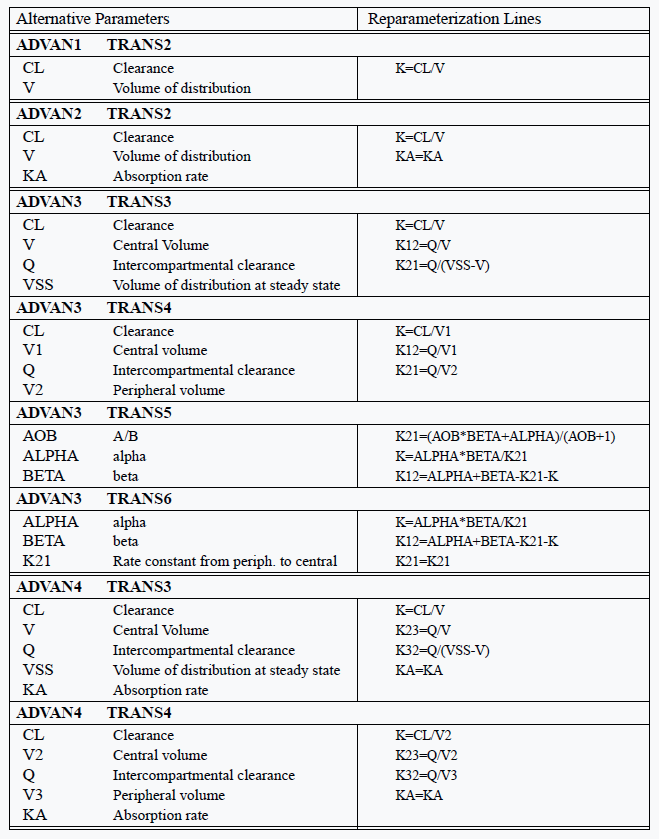

## `[ pkmodel ]`

`mrgsolve`

```cpp
[ pkmodel ] cmt = "CENT"           , depot = FALSE // 1-cmt IV
[ pkmodel ] cmt = "GUT CENT"       , depot = TRUE  // 1-cmt oral/SC
[ pkmodel ] cmt = "CENT PHRIPH"    , depot = FALSE // 2-cmt IV
[ pkmodel ] cmt = "GUT CENT PHRIPH", depot = TRUE  // 2-cmt oral/SC
```

`NONMEM`

```cpp
$SUBROUTINE ADVAN1 TRANS2; 1-CMT IV
$SUBROUTINE ADVAN2 TRANS2; 1-CMT oral/SC
$SUBROUTINE ADVAN3 TRANS4; 2-CMT IV
$SUBROUTINE ADVAN4 TRANS4; 2-CMT oral/SC
```

# `[ plugin ]`

- `autodec`
- `nm-vars`
- `Rcpp`

## `autodec`

Typical way…

```cpp
[ pk ]
  double V2WT   = log(WT/70.0);
  double CLWT   = log(WT/70.0)*0.75;
  double CLEGFR = log(EGFR/90.0)*THETA(6);
  double CLAGE  = log(AGE/35.0)*THETA(7);
  double V3WT   = log(WT/70.0);
  double QWT    = log(WT/70.0)*0.75;
  double CLALB  = log(ALB/4.5)*THETA(8);

  double KA  = exp(THETA(1) + ETA(1));
  double V2  = exp(THETA(2) + V2WT + ETA(2));
  double CL  = exp(THETA(3) + CLWT + CLEGFR + CLAGE + CLALB + ETA(3));
  double V3  = exp(THETA(4) + V3WT);
  double Q   = exp(THETA(5) + QWT);

  double S2 = V2/1000.0; //; dose in mcg, conc in mcg/mL
```

With `autodec`

```cpp
[ plugin ] autodec

...

[ pk ]
  V2WT   = log(WT/70.0);
  CLWT   = log(WT/70.0)*0.75;
  CLEGFR = log(EGFR/90.0)*THETA(6);
  CLAGE  = log(AGE/35.0)*THETA(7);
  V3WT   = log(WT/70.0);
  QWT    = log(WT/70.0)*0.75;
  CLALB  = log(ALB/4.5)*THETA(8);

  KA  = exp(THETA(1) + ETA(1));
  V2  = exp(THETA(2) + V2WT + ETA(2));
  CL  = exp(THETA(3) + CLWT + CLEGFR + CLAGE + CLALB + ETA(3));
  V3  = exp(THETA(4) + V3WT);
  Q   = exp(THETA(5) + QWT);

  S2 = V2/1000.0; //; dose in mcg, conc in mcg/mL
```

## `autodec`

When this plugin is invoked, `mrgsolve` will search your model code for assignments and automatically declare them as double precision numbers (`double`). The following blocks are searched

- `$PREAMBLE`
- `$MAIN` (or `$PK`)
- `$ODE` (or `$DES`)
- `$TABLE` (or `$ERROR`)
- `$PRED`

## Skip `autodec` a variable

- When you are using the `autodec` plugin, you can still declare variables as `double` or `int` or `bool`. `mrgsolve` already finds those variables and will understand to leave those declarations alone.

```cpp
[ plugin ] autodec

...

[ pk ]
  V2  = exp(THETA(2) + V2WT + ETA(2));
  int n = 2;
  bool ddi = TRUE;
```

- In case mrgsolve does try to declare (as `double`) a variable that shouldn’t be handled that way, you can note this name in an environment variable inside your model called `MRGSOLVE_AUTODEC_SKIP`.

```cpp
[ env ] MRGSOLVE_AUTODEC_SKIP = c("my_variable_1")
```

## `NONMEM` versus `mrgsolve` without `nm-vars`

`NONMEM`

```cpp
$PK
...
KA   = EXP(THETA(1)+ETA(1))
V2   = EXP(THETA(2)+V2WT+ETA(2))
CL   = EXP(THETA(3)+CLWT+CLEGFR+CLAGE+CLALB+ETA(3))
V3   = EXP(THETA(4)+V3WT)
Q    = EXP(THETA(5)+QWT)
...
F1    = LOG(THETA(10))
ALAG1 = SQRT(THETA(11))
...
$DES
DADT(1) = - KA * A(1)
DADT(2) = KA * A(1) - (CL/V)*A(2) - Q*(A(2)/V2 - A(3)/V3)
DADT(3) = Q*(A(2)/V2 - A(3)/V3)
...
```

`mrgsolve`

```cpp
[ pk ]
...
double KA  = exp(THETA(1) + ETA(1));
double V2  = exp(THETA(2) + V2WT + ETA(2));
double CL  = exp(THETA(3) + CLWT + CLEGFR + CLAGE + CLALB + ETA(3));
double V3  = exp(THETA(4) + V3WT);
double Q   = exp(THETA(5) + QWT);
...
F_CENT    = log(THETA(10));
ALAG_CENT = sqrt(THETA(11));
...
[ ode ]
dxdt_DEPOT = - KA * DEPOT;
dxdt_CENT = KA * DEPOT - (CL/V)*CENT - Q*(CENT/V2 - PERIPH/V3);
dxdt_PERIPH = Q*(CENT/V2 - PERIPH/V3);
...
```

## `NONMEM` versus `mrgsolve` with `nm-vars`

`NONMEM`

```cpp
$PK
...
KA   = EXP(THETA(1)+ETA(1))
V2   = EXP(THETA(2)+V2WT+ETA(2))
CL   = EXP(THETA(3)+CLWT+CLEGFR+CLAGE+CLALB+ETA(3))
V3   = EXP(THETA(4)+V3WT)
Q    = EXP(THETA(5)+QWT)
...
F1    = LOG(THETA(10))
ALAG1 = SQRT(THETA(11))
...
$DES
DADT(1) = - KA * A(1)
DADT(2) = KA * A(1) - (CL/V)*A(2) - Q*(A(2)/V2 - A(3)/V3)
DADT(3) = Q*(A(2)/V2 - A(3)/V3)
...
```

`mrgsolve` with `nm-vars`

```cpp
[ plugin ] nm-vars

...

[ pk ]
...
double KA  = EXP(THETA(1) + ETA(1));
double V2  = EXP(THETA(2) + V2WT + ETA(2));
double CL  = EXP(THETA(3) + CLWT + CLEGFR + CLAGE + CLALB + ETA(3));
double V3  = EXP(THETA(4) + V3WT);
double Q   = EXP(THETA(5) + QWT);
...
F1    = LOG(THETA(10));
ALAG1 = SQRT(THETA(11));
...
[ ode ]
DADT(1) = - KA * A(1);
DADT(2) = KA * A(1) - (CL/V)*A(2) - Q*(A(2)/V2 - A(3)/V3);
DADT(3) = Q*(A(2)/V2 - A(3)/V3);
...
```

## `[ plugin ] nm-vars`

- `F`, `R`, `D`, `ALAG`
  - To set bioavailability for the nth compartment, use `Fn`.
  - To set the infusion rate for the nth compartment, use `Rn`.
  - To set the infusion duration for the nth compartment, use `Dn`.
  - To set the lag time for the nth compartment, use `ALAGn`.
- `A`, `A_0`, `DADT`.
  - To refer to the amount in the nth compartment, use `A(n)`.
  - To refer to the initial amount in the nth compartment, use `A_0(n)`.
  - To refer to the differential equation for the nth compartment, use `DADT(n)`.
- Math.
  - `EXP(a)` gets mapped to `exp(a)`.
  - `LOG(a)` gets mapped to `log(a)`.
  - `SQRT(a)` gets mapped to `sqrt(a)`.
- Use `T` in `$DES` to refer to the current time in the ode solver rather than `SOLVERTIME`

## `Rcpp`

- This gives you functions and data structures that you’re used to using in `R`, but they work in `C++`.
- The main use for this is random number generation. Any `d/q/p/r` function in `R` will be available; arguments are the same, but omit n (you always get just one draw when calling from `C++`.
- Note: this will slightly increase compile time.

```cpp
$PLUGIN Rcpp

$ERROR
double u = R::runif(0, 1);
```

## Many other `[ plugin ]`

- `tad`
- `evtools`
- `CXX11`
- `mrgx`
- `RcppArmadillo`
- `BH`

Resource: https://mrgsolve.org/user-guide/plugins.html

# Other blocks

- `[ setup ]`
- `[ env ]`
- `[ pred ]`
- `[ premable ]`
- `[ global ]`

## `[ set ]`

- To configure the model object on load.

```cpp
[ set ] end = 240, delta = 0.5, req = "IPRED"
```

## `[ env ]`

- To define a set of `R` objects that might be evaluated in other model blocks.
- This block is all `R` code (just as you would code in a stand-alone R script.

```cpp
...
$ENV

Sigma <- cmat(1,0.6,2)

rescale <- 1/1000

convert <- function(x) x * 5 / 166.2
...
$PARAM
p = 500 * rescale
q  = convert(2.51)
...
$OMEGA @object Sigma
...
```

## `[ pred ]`

- Use `$PRED` to write a model **without** differential equations.
- In this block, write all algebraic expressions for derived parameters, the response, and any other derived output quantities.
- It is an error to include the following blocks when `$PRED` is being used: `$MAIN`, `$TABLE`, `$PKMODEL`, `$ODE`, `$CMT`, `$INIT`.

## An example model using `$PRED`

`NONMEM`

```cpp
$PROBLEM A MODEL WITH $PRED
$INPUT ID TIME DV AUC
$DATA SOMEDATA
$PRED
 EVE0=THETA(1)
 E0=EVE0*EXP(ETA(1))
 IMAX=40
 AUC50=100
 R=E0-IMAX*AUC/(AUC50+AUC)
 Y=R+EPS(1)
$THETA   100
$OMEGA   0.1
$SIGMA   4
$ESTIMATION
```

`mrgsolve`

```cpp
[ PARAM ]
TVE0 = 100
AUC50 = 100
IMAX = 40
AUC = 0
[ OMEGA ] 0.1
[ SIGMA ] 4
[ PRED ]
double E0=EVE0*exp(ETA(1));
double R=E0-IMAX*AUC/(AUC50+AUC);
double Y=R+EPS(1);
```

## `[ premable ]`

- Only called one time during the simulation run (right at the start). The code in this block is typically used to configure or initialize `C++` variables or data structures that were declared in `[ global ]`.

```cpp
[ PLUGIN ] Rcpp

[ GLOBAL ]
namespace{
  Rcpp::NumericVector x;
}

[ PREAMBLE ]
x.push_back(5.0); // add the 1st element in vector x
x.push_back(6.0); // add the 2nd element in vector x
x.push_back(7.0); // add the 3rd element in vector x

[ MAIN ]
double CL=x[0]; // 1st value of x
double V =x[1]; // 2nd value of x
double KA=x[2]; // 3rd value of x
```

## `[ global ]`

- To define variables outside of any other block
- Two more-common uses:
  - Write `#define` preprocessor statements.
  - Define global variables (e.g., `double`, `bool`, `int`)

```cpp
[ global ] #define CP (CENT/S2)
```

```cpp
[ global ] double CP = 0;
...
[ error ]
    CP = CENT/S2;
```

# Variables and macros

https://mrgsolve.org/user-guide/specification.html#sec-variables-macros

```r
double mt1 = self.mtime(1.23 + ETA(1));
self.mevent(1.23 + ETA(1), 33);
```

# Validation

- Once we finished developing a popPK model using `NONMEM`, it is common that we translate a `NONMEM` model into a `mrgsolve` model for simulation.
- Validation needs to be done to confirm the correctness of the translation by comparing:
  - `PRED`: `NONMEM` vs `mrgsolve`.
  - `IPRED`: `NONMEM` vs `mrgsolve`.

# Homework

- Translate a `NONMEM` model (`./wk6/nm-model/hwwk6.mod`) into a `mrgsolve` model.
  - Capture the individual predictions as a variable named `IPRED`.
- Perform validation using the script (`./wk6/validation_hwwk6.qmd`). Knit into a `html` file for submission.
- Deadline: **Oct. 25 2024**
- We will use the first hour of the Oct. 18 in-class lecture to work on this together. So feel free to explore it by yourself before Oct. 18 lecture.